# Mobiquity Metereological Dataset

And because wind affects ozone concentration how does a plot including ozone, temp and wind look?

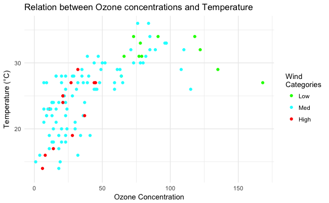

```r
ggplot(meteo, aes(x=Ozone.concentration, y= Temperature.C, colour=wind_cat))+ geom_point()+
  labs(title="Relation between Ozone concentrations and Temperature", x= "Ozone Concentration", y= "Temperature (°C)") + theme_minimal()+
  scale_color_manual(name="Wind \nCategories",
                         values = c("Green",
                                    "cyan",
                                    "Red"),
                     labels = c("Low ","Med","High"))
```

```r
NA
```

Doing the same for different radiation categories?

```r
ggplot(meteo, aes(x= Radiation)) + geom_density() + geom_vline(xintercept = 150) + geom_vline(xintercept=280)
```

[output not shown]

```r
lbr = 50
hbr = 270
#Making 3 categories for low/medium/high rad categories
meteo$rad_cat <- 2 #standaard als gemiddelde sterkte

for (i in 1:length(meteo$Radiation)){
  if (is.na(meteo$Radiation[i])){
    meteo$rad_cat[i]= 0
  }
  else {
    if(meteo$Radiation[i] <= lbr){
      meteo$rad_cat[i]= 1
      }
    if (meteo$Radiation[i] >= hbr){
      meteo$rad_cat[i] = 3
      }
  }
}
meteo$rad_cat <- as.factor(meteo$rad_cat)

count(meteo, "rad_cat")
meteo
```

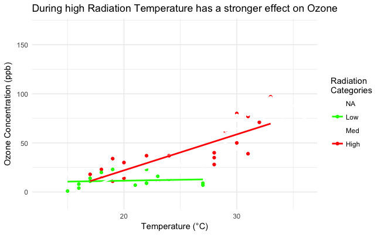

```r
ggplot(meteo, aes(y=Ozone.concentration, x= Temperature.C, colour=rad_cat))+ geom_point()+
  geom_smooth(method="lm", se=F,)+
  labs(title="During high Radiation Temperature has a stronger effect on Ozone", y= "Ozone Concentration (ppb)", x= "Temperature (°C)") + theme_minimal()+
  scale_color_manual(name="Radiation \nCategories",
                         values = c("white","Green",
                                    "white",
                                    "Red"),
                     labels = c("NA","Low ","Med","High"))
```

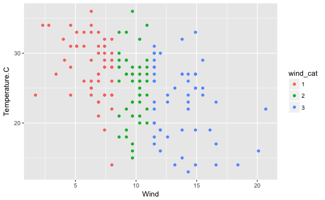

```r
ggplot(meteo,aes( x=Wind, y= Temperature.C, col= wind_cat)) + geom_point()
```

Low Radiation category (<50) results in lower Ozone concentration but high does not result in higher values per ce. There are however 42 rows where either concentration or radiation is missing which is 27% and quite a lot for such a small dataset.

```r
missing = sum(is.na(meteo$Ozone.concentration) | is.na(meteo$Radiation))
missing_p= 42/length(meteo$Ozone.concentration)*100
missing_p
```

```r
lbb = 20
hbb = 30
#Making 3 categories for low/medium/high temperatures
meteo$temp_cat<- 0
for (i in 1:length(meteo$Temperature.C)){
  if(meteo$Temperature.C[i] <= lbb){
  meteo$temp_cat[i]= 1
  }
  else {
    if (meteo$Temperature.C[i] >= hbb){
    meteo$temp_cat[i] = 3
    }
    else {
       meteo$temp_cat[i] = 2
    }
  }
}
meteo$temp_cat <- as.factor(meteo$temp_cat)
```

```r
lbbb = 40
hbbb = 110
#Making 3 categories for low/medium/high temperatures
meteo$time_cat<- 0
for (i in 1:length(meteo$Temperature.C)){
  if(meteo$X[i] <= lbbb){
  meteo$time_cat[i]= 1
  }
  else {
    if (meteo$X[i] >= hbbb){
    meteo$time_cat[i] = 3
    }
    else {
       meteo$time_cat[i] = 2
    }
  }
}
meteo$time_cat <- as.factor(meteo$time_cat)
```

```r
lbbb = 30
hbbb = 70
#Making 3 categories for low/medium/high temperatures
meteo$oz_cat<- 2
for (i in 1:length(meteo$Radiation)){
  if (is.na(meteo$Ozone.concentration[i])){
    meteo$oz_cat[i]= 0
  }
  else {
    if(meteo$Ozone.concentration[i] <= lbbb){
      meteo$oz_cat[i]= 1
      }
    if (meteo$Ozone.concentration[i] >= hbbb){
      meteo$oz_cat[i] = 3
      }
  }
}
meteo$oz_cat <- as.factor(meteo$oz_cat)
count(meteo, "oz_cat")
```

| oz_cat | freq |
| --- | --- |
| 0 | 37 |
| 1 | 57 |
| 2 | 34 |
| 3 | 25 |

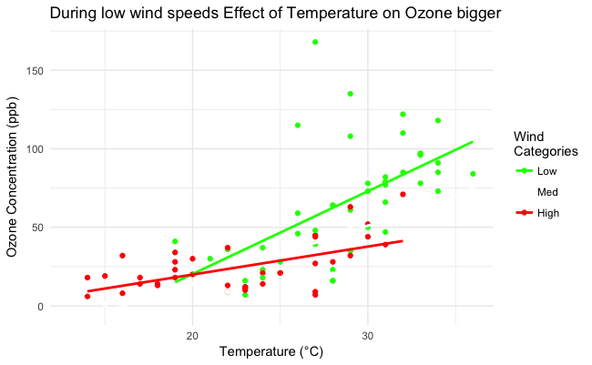

```r
ggplot(meteo, aes(y=Ozone.concentration, x=Temperature.C, colour=wind_cat))+ geom_point()+
  geom_smooth(method= "lm",se=F,) +
  labs(title="During low wind speeds Effect of Temperature on Ozone bigger",
       y= "Ozone Concentration (ppb)",
       x= "Temperature (°C)") + theme_minimal()+
  scale_color_manual(name="Wind \nCategories",
                         values = c("Green",
                                    "white",
                                    "Red"),
                     labels = c("Low ","Med","High"))
```

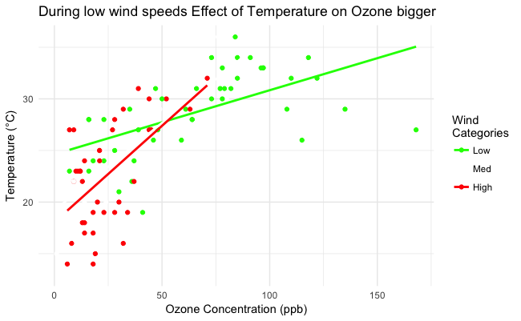